# Week 1

Chris Beeley

08/03/2021

## Chapter 4

### E1

In the model below, which line is the likelihood:

$$y_{i} \sim Normal(\mu, \sigma)$$
$$\mu \sim Normal(0, 10)$$
$$\sigma \sim Exponential(1)$$

Top line (the other lines are priors).

### E2

In the model definition above, how many parameters are in the posterior distribution?

Two. Mu and sigma

### E3

Using the model definition above, write down the appropriate form of Bayes’ theorem that includes the proper likelihood and priors.

$$Pr(\mu, \sigma | y_{i}) = \frac{Normal(y_{1} | \mu, \sigma).Normal(p |0, 10)}{\int Normal(y_{1} | \mu, \sigma).Normal(p| 0, 10) d\mu}$$

I have no clue, to be honest

### E4

In the model definition below, which line is the linear model?

$$y_{i} \sim Normal(\mu, \sigma)$$
$$\mu_{i} = \alpha + \beta x_{i}$$
$$\alpha \sim Normal(0, 10)$$
$$\beta \sim Normal(0, 1)$$
$$\sigma \sim Exponential(2)$$

Line two is the linear model.

### E5

In the model above, how many parameters are in the posterior distribution? Three- $\alpha$, $\beta$, and $\sigma$.

### M1

For the following model, simulate observed values from the prior:

$$y_{i} \sim Normal(\mu, \sigma)$$
$$\mu \sim Normal(0, 10)$$
$$\sigma \sim Exponential(1)$$
Plot it first:

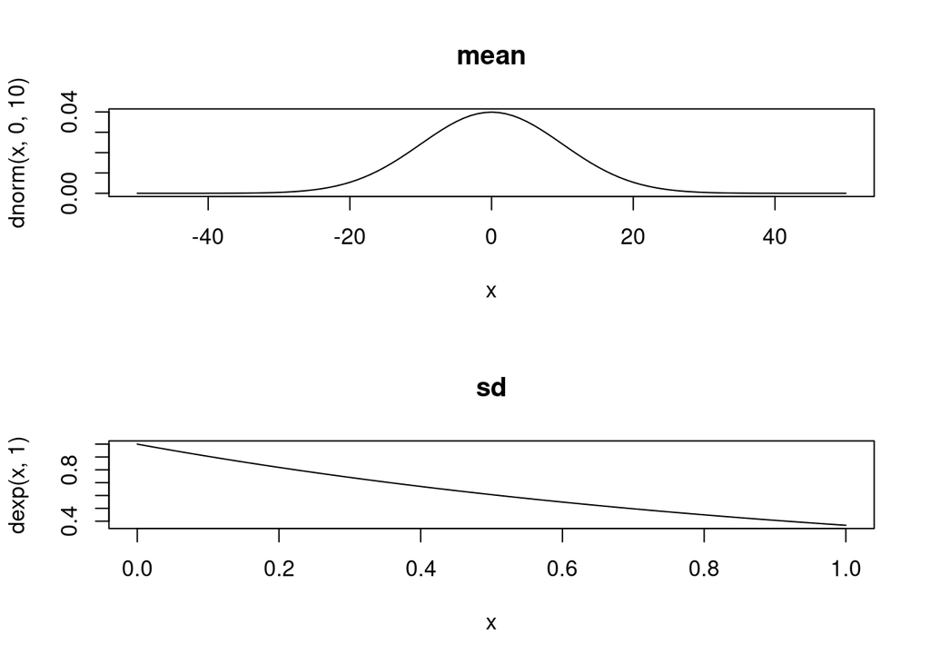

```r
par(mfrow = c(2, 1))

curve(dnorm(x, 0, 10), from = -50, to = 50, main = "mean")
curve(dexp(x, 1), from = 0, to = 1, main = "sd")
```

```r
par(mfrow = c(1, 1))
```

Now sample from it

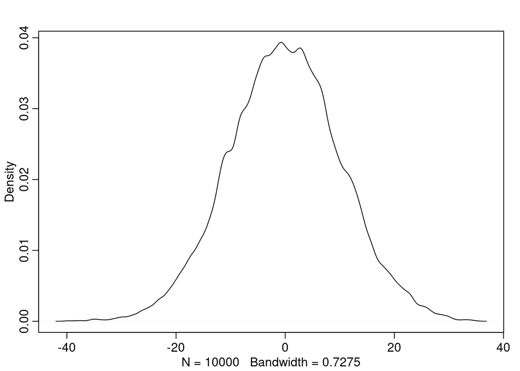

```r
sample_mu <- rnorm(1e4, 0, 10)
sample_sigma <- rexp(1e4, 1)

prior <- rnorm(1e4, sample_mu, sample_sigma)
dens(prior)
```

### M2

Translate the model above into a quap formula

```r
flist <- alist(
  value ~ dnorm(mu, sigma),
  mu ~ dnorm(0, 10),
  sigma ~ dexp(1)
)
```

### M3

Translate the following code into a mathematical formula

```r
y ~ dnorm(mu, sigma)
mu <- a + b * x
a ~ dnorm(0, 10)
b ~ dunif(0, 1)
sigma ~ dexp(1)
```

$$y_{i} \sim Normal(\mu, \sigma)$$
$$\mu_{i} = a + \beta x_{i}$$
$$a \sim Normal(0, 10)$$
$$b \sim Uniform(0, 1)$$
$$\sigma \sim Exponential(1)$$

### M4

A sample of students is measured for height each year for 3 years. After three years you want to fit a linear regression predicting height using year as a predictor. Write down the model and the priors.

$$y_{i} \sim Normal(\mu, \sigma)$$
$$\mu_{i} = a + \beta x_{i}$$
$$a \sim Normal(178, 30)$$
$$b \sim Normal(0, 2)$$
$$\sigma \sim Uniform(50)$$
### M5

Suppose I reminded you that every student gets taller each year. How would that affect the prior?

$$b \sim Uniform(0, 5)$$

### M6

Now suppose I tell you that the variance of height is never more than 64cm. How does this lead you to revise your priors?

$$\sigma \sim Uniform(8)$$

### M7

Refit the model again without xbar for weight this time

Original code:

```r
library(rethinking)
data(Howell1)
d <- Howell1
d2 <- d[ d$age >= 18 , ]

# define the average weight, x-bar
xbar <- mean(d2$weight)

# fit model
m4.3 <- quap(
    alist(
        height ~ dnorm( mu , sigma ) ,
        mu <- a + b*( weight - xbar ) ,
        a ~ dnorm( 178 , 20 ) ,
        b ~ dlnorm( 0 , 1 ) ,
        sigma ~ dunif( 0 , 50 )
    ) , data=d2 )

## R code 4.44
precis( m4.3 )
```

```
##              mean         sd        5.5%       94.5%
## a     154.6013651 0.27030777 154.1693611 155.0333692
## b       0.9032808 0.04192365   0.8362787   0.9702829
## sigma   5.0718830 0.19115498   4.7663804   5.3773856
```

```r
## R code 4.45
round( vcov( m4.3 ) , 3 )
```

```
##           a     b sigma
## a     0.073 0.000 0.000
## b     0.000 0.002 0.000
## sigma 0.000 0.000 0.037
```

New model

```r
library(rethinking)
data(Howell1)
d <- Howell1
d2 <- d[ d$age >= 18 , ]

# fit model
m.new <- quap(
    alist(
        height ~ dnorm( mu , sigma ) ,
        mu <- a + b*( weight) ,
        a ~ dnorm( 178 , 20 ) ,
        b ~ dlnorm( 0 , 1 ) ,
        sigma ~ dunif( 0 , 50 )
    ) , data=d2 )

## R code 4.44
precis( m.new )
```

```
##              mean         sd        5.5%      94.5%
## a     114.5329414 1.89772998 111.5000024 117.565880
## b       0.8908004 0.04175753   0.8240638   0.957537
## sigma   5.0726797 0.19124518   4.7670330   5.378326
```

```r
## R code 4.45
round( vcov( m.new ) , 3 )
```

```
##            a      b sigma
## a      3.601 -0.078 0.009
## b     -0.078  0.002 0.000
## sigma  0.009  0.000 0.037
```